# MLS Match Result Prediction

Your Name

2026-03-26

## 1. Introduction

This report develops a machine learning model to predict MLS match outcomes — classified as **home win**, **away win**, or **draw** — using a Random Forest classifier trained on historical match and team statistics sourced from a custom MySQL database.

The methodology follows three stages:

1. **Feature selection** — identifying the most predictive variables using two independent methods
2. **Temporal validation** — training on 2024 data and evaluating on unseen 2025 data
3. **Live prediction** — retraining on 2024–2025 data to predict early 2026 matches with known outcomes

A temporal train/test split is used rather than random splitting, as it more accurately reflects a real-world forecasting scenario where only past data is available at prediction time.

## 2. Libraries & Database Connection

```r
library(DBI)
library(RMySQL)
library(dplyr)
library(tidyr)
library(ggplot2)
library(randomForest)
library(caret)
```

```r
con <- dbConnect(
  RMySQL::MySQL(),
  host     = "o8ukkP9TliImN.h.filess.io",
  dbname   = "MLS",
  user     = "root",
  password = "!wMoU9lBdLZWW6Y8",
  port     = 58202
)
```

## 3. Load Data

```r
matches            <- dbReadTable(con, "matches")
match_team_stats   <- dbReadTable(con, "match_team_stats")
match_player_stats <- dbReadTable(con, "match_player_stats")
team_stats         <- dbReadTable(con, "team_stats")
players_stats      <- dbReadTable(con, "players_stats")
team_roster        <- dbReadTable(con, "team_roster")
teams              <- dbReadTable(con, "teams")

# Parse dates
matches$date            <- as.Date(matches$date)
team_stats$date         <- as.Date(team_stats$date)
team_roster$stint_start <- as.Date(team_roster$stint_start)
team_roster$stint_end   <- as.Date(team_roster$stint_end)

# Map team abbreviation -> team_id
abbr_to_id           <- setNames(teams$team_id, teams$team_abbr)
matches$home_team_id <- abbr_to_id[matches$home_team]
matches$away_team_id <- abbr_to_id[matches$away_team]

cat("Total matches loaded:", nrow(matches), "\n")
```

```
## Total matches loaded: 1506
```

## 4. Target Variable

Match outcomes are encoded as a three-class factor. Home and away wins are kept distinct rather than collapsed to a binary win/loss, as home advantage is a well-documented phenomenon in professional football.

```r
matches$result <- case_when(
  matches$home_score > matches$away_score ~ "home_win",
  matches$home_score < matches$away_score ~ "away_win",
  TRUE                                    ~ "draw"
)
matches$result <- factor(matches$result)

cat("Overall class distribution:\n")
```

```
## Overall class distribution:
```

```r
table(matches$result)
```

```
##
## away_win     draw home_win
##      426      393      687
```

## 5. Feature Engineering

### 5.1 Block A — Match Team Statistics

In-match team performance metrics from `match_team_stats`. Four columns that directly encode the scoreline (goals scored/conceded) are removed to prevent leakage.

```r
leaky_cols <- c("shooting_goals_home", "shooting_goals_away",
                "general_goals_conceded_home", "general_goals_conceded_away")

block_a <- match_team_stats %>%
  select(-any_of(leaky_cols))

cat("Block A features:", ncol(block_a) - 1, "\n")
```

```
## Block A features: 104
```

### 5.2 Block B — Match Player Statistics

Per-player match statistics from `match_player_stats` aggregated to match level. Counting stats (assists, passes, etc.) are summed across all players; percentage stats are averaged.

```r
pct_cols <- names(match_player_stats)[grepl("perc", names(match_player_stats))]

block_b <- match_player_stats %>%
  group_by(match_id) %>%
  summarise(
    across(all_of(pct_cols), \(x) mean(x, na.rm = TRUE)),
    across(-all_of(c("player_id", pct_cols)), \(x) sum(x, na.rm = TRUE)),
    .groups = "drop"
  )

names(block_b)[-1] <- paste0("player_", names(block_b)[-1])

cat("Block B features:", ncol(block_b) - 1, "\n")
```

```
## Block B features: 27
```

### 5.3 Block C — Team Ratings

FIFA-style team ratings (overall, attack, midfield, defence) from `team_stats`. For each match, the most recent snapshot **before** the match date is selected separately for both the home and away team.

```r
rating_cols <- c("overall", "attack", "midfield", "defence")

latest_rating <- function(team_id, match_date) {
  subset <- team_stats %>%
    filter(team_id == !!team_id, date <= match_date) %>%
    arrange(desc(date)) %>%
    slice(1)

  # If no prior snapshot, use the earliest available
  if (nrow(subset) == 0) {
    subset <- team_stats %>%
      filter(team_id == !!team_id) %>%
      arrange(date) %>%
      slice(1)
  }

  if (nrow(subset) == 0) {
    return(setNames(rep(NA_real_, length(rating_cols)), rating_cols))
  }
  as.numeric(subset[, rating_cols])
}

cat("Joining team ratings...\n")
```

```
## Joining team ratings...
```

```r
block_c <- matches %>%
  select(match_id, date, home_team_id, away_team_id) %>%
  rowwise() %>%
  mutate(
    home_r = list(latest_rating(home_team_id, date)),
    away_r = list(latest_rating(away_team_id, date))
  ) %>%
  ungroup() %>%
  mutate(
    team_overall_home  = sapply(home_r, `[[`, 1),
    team_attack_home   = sapply(home_r, `[[`, 2),
    team_midfield_home = sapply(home_r, `[[`, 3),
    team_defence_home  = sapply(home_r, `[[`, 4),
    team_overall_away  = sapply(away_r, `[[`, 1),
    team_attack_away   = sapply(away_r, `[[`, 2),
    team_midfield_away = sapply(away_r, `[[`, 3),
    team_defence_away  = sapply(away_r, `[[`, 4)
  ) %>%
  select(match_id, starts_with("team_"))

cat("Block C features:", ncol(block_c) - 1, "\n")
```

```
## Block C features: 8
```

### 5.4 Block D — Squad Player Ratings

FIFA attribute ratings from `players_stats` averaged per squad per match. Active squad members are identified via `team_roster` using stint start and end dates.

```r
ps_num_cols <- names(players_stats)[sapply(players_stats, is.numeric)]
ps_num_cols <- setdiff(ps_num_cols, "player_id")

get_squad_avg <- function(team_id, match_date) {
  squad_ids <- team_roster %>%
    filter(
      team_id == !!team_id,
      stint_start <= !!match_date,
      is.na(stint_end) | stint_end >= !!match_date
    ) %>%
    pull(player_id)

  squad_stats <- players_stats %>% filter(player_id %in% squad_ids)
  if (nrow(squad_stats) == 0) return(setNames(rep(NA_real_, length(ps_num_cols)), ps_num_cols))
  colMeans(squad_stats[, ps_num_cols], na.rm = TRUE)
}

cat("Averaging squad ratings (slowest step)...\n")
```

```
## Averaging squad ratings (slowest step)...
```

```r
total      <- nrow(matches)
squad_rows <- vector("list", total)

for (i in seq_len(total)) {
  if (i %% 100 == 0 || i == total) cat("  Progress:", i, "/", total, "\n")
  m <- matches[i, ]
  h <- get_squad_avg(m$home_team_id, m$date)
  a <- get_squad_avg(m$away_team_id, m$date)
  squad_rows[[i]] <- c(
    match_id = m$match_id,
    setNames(h, paste0("squad_", ps_num_cols, "_home")),
    setNames(a, paste0("squad_", ps_num_cols, "_away"))
  )
}
```

```
##   Progress: 100 / 1506
##   Progress: 200 / 1506
##   Progress: 300 / 1506
##   Progress: 400 / 1506
##   Progress: 500 / 1506
##   Progress: 600 / 1506
##   Progress: 700 / 1506
##   Progress: 800 / 1506
##   Progress: 900 / 1506
##   Progress: 1000 / 1506
##   Progress: 1100 / 1506
##   Progress: 1200 / 1506
##   Progress: 1300 / 1506
##   Progress: 1400 / 1506
##   Progress: 1500 / 1506
##   Progress: 1506 / 1506
```

```r
block_d            <- as.data.frame(do.call(rbind, squad_rows))
block_d$match_id   <- matches$match_id
block_d            <- block_d %>% mutate(across(-match_id, as.numeric))

cat("Block D features:", ncol(block_d) - 1, "\n")
```

```
## Block D features: 88
```

## 6. Combine & Clean

```r
df_full <- matches %>%
  select(match_id, date, result) %>%
  left_join(block_a, by = "match_id") %>%
  left_join(block_b, by = "match_id") %>%
  left_join(block_c, by = "match_id") %>%
  left_join(block_d, by = "match_id")

# Only drop rows where final model features are missing
# Define final_features first or hardcode them here
keep_cols <- c(
  "match_id", "date", "result",
  "general_shots_on_goal_home", "general_shots_on_goal_away",
  "general_expected_goals_away", "general_total_crosses_home",
  "general_total_crosses_away", "general_clearances_away",
  "possession_81_85_home", "possession_81_85_away",
  "possession_86_90_home", "possession_86_90_away",
  "xg_total_team_xg_home", "xg_total_team_xg_away"
)

df_full <- df_full %>% drop_na(any_of(keep_cols))

cat("Final dataset:", nrow(df_full), "matches\n")
```

```
## Final dataset: 1029 matches
```

```r
cat("Date range:", format(min(df_full$date)), "to", format(max(df_full$date)), "\n")
```

```
## Date range: 2024-02-21 to 2026-03-08
```

```r
table(df_full$result)
```

```
##
## away_win     draw home_win
##      320      250      459
```

## 7. Feature Selection

### 7.1 Method 1 — Random Forest Gini Importance

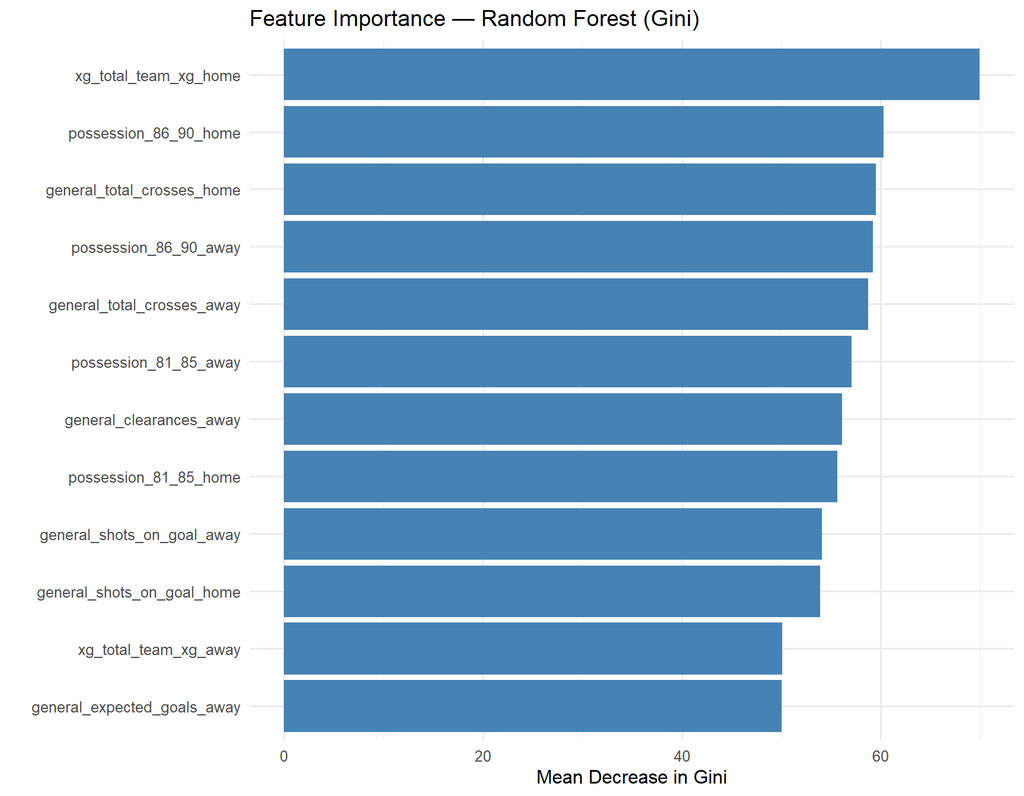

```r
df_rf <- df_full %>%
  select(all_of(keep_cols)) %>%
  drop_na()

feature_cols <- setdiff(keep_cols, c("match_id", "date", "result"))
X_all <- df_rf[, feature_cols]
y_all <- df_rf$result

set.seed(42)
rf_screen <- randomForest(
  x          = X_all,
  y          = y_all,
  ntree      = 200,
  importance = TRUE,
  classwt    = c(home_win = 1, away_win = 1, draw = 1)
)

imp_df <- data.frame(
  feature    = rownames(importance(rf_screen)),
  importance = importance(rf_screen)[, "MeanDecreaseGini"]
) %>% arrange(desc(importance))

imp_df %>%
  head(12) %>%
  mutate(feature = reorder(feature, importance)) %>%
  ggplot(aes(x = importance, y = feature)) +
  geom_col(fill = "steelblue") +
  labs(title = "Feature Importance — Random Forest (Gini)",
       x = "Mean Decrease in Gini", y = "") +
  theme_minimal(base_size = 12)
```

### 7.2 Method 2 — Pearson Correlation with Target

The target is numerically encoded (home_win = 3, draw = 2, away_win = 1) and absolute Pearson correlation is computed for each feature. Using two independent methods ensures that selected features have convergent evidence of predictive value.

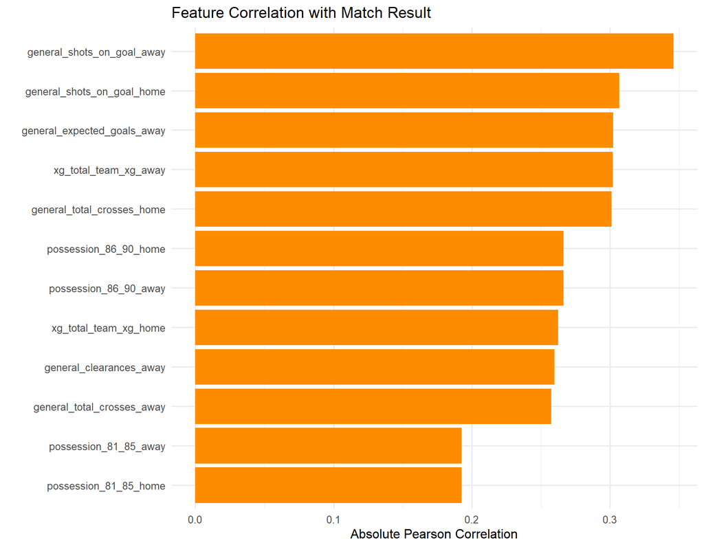

```r
result_num <- as.numeric(factor(df_rf$result, levels = c("away_win", "draw", "home_win")))

corr_vals <- sapply(X_all, function(col) {
  if (sd(col, na.rm = TRUE) == 0) return(0)
  abs(cor(col, result_num, use = "complete.obs"))
})

corr_df <- data.frame(
  feature     = names(corr_vals),
  correlation = corr_vals
) %>% arrange(desc(correlation))

corr_df %>%
  head(12) %>%
  mutate(feature = reorder(feature, correlation)) %>%
  ggplot(aes(x = correlation, y = feature)) +
  geom_col(fill = "darkorange") +
  labs(title = "Feature Correlation with Match Result",
       x = "Absolute Pearson Correlation", y = "") +
  theme_minimal(base_size = 12)
```

### 7.3 Final Feature Set

Features appearing in the top of both methods are selected, providing convergent evidence of predictive value.

```r
top_rf   <- head(imp_df, 12)$feature
top_corr <- head(corr_df, 12)$feature
final_features <- intersect(top_rf, top_corr)

if (length(final_features) < 6) {
  final_features <- head(imp_df, 12)$feature
}

cat("Top RF features:   ", length(top_rf), "\n")
```

```
## Top RF features:    12
```

```r
cat("Top corr features: ", length(top_corr), "\n")
```

```
## Top corr features:  12
```

```r
cat("Agreed (final):    ", length(final_features), "\n\n")
```

```
## Agreed (final):     12
```

```r
for (f in sort(final_features)) cat(" ", f, "\n")
```

```
##   general_clearances_away
##   general_expected_goals_away
##   general_shots_on_goal_away
##   general_shots_on_goal_home
##   general_total_crosses_away
##   general_total_crosses_home
##   possession_81_85_away
##   possession_81_85_home
##   possession_86_90_away
##   possession_86_90_home
##   xg_total_team_xg_away
##   xg_total_team_xg_home
```

## 8. Temporal Train / Test Split

Rather than a random train/test split, we use a **temporal split** — training on 2024 matches and evaluating on 2025 matches. This is more appropriate for sports prediction since it mirrors real deployment conditions: only historical data is ever available when making predictions.

```r
df_model <- df_full %>% select(all_of(c("match_id", "date", "result", final_features)))

train_df <- df_model %>% filter(format(date, "%Y") == "2024")
test_df  <- df_model %>% filter(format(date, "%Y") == "2025")

cat("Training set (2024):", nrow(train_df), "matches\n")
```

```
## Training set (2024): 484 matches
```

```r
cat("Test set (2025):    ", nrow(test_df),  "matches\n\n")
```

```
## Test set (2025):     501 matches
```

```r
cat("Training class distribution:\n")
```

```
## Training class distribution:
```

```r
print(table(train_df$result))
```

```
##
## away_win     draw home_win
##      152      119      213
```

```r
cat("\nTest class distribution:\n")
```

```
##
## Test class distribution:
```

```r
print(table(test_df$result))
```

```
##
## away_win     draw home_win
##      156      125      220
```

## 9. Model Training — Random Forest

```r
X_train <- train_df[, final_features]
y_train <- train_df$result

set.seed(42)
rf_model <- randomForest(
  x       = X_train,
  y       = y_train,
  ntree   = 500,
  mtry    = floor(sqrt(length(final_features))),  # standard for classification
  classwt = c(home_win = 1, away_win = 1, draw = 1),
  importance = TRUE
)

print(rf_model)
```

```
##
## Call:
##  randomForest(x = X_train, y = y_train, ntree = 500, mtry = floor(sqrt(length(final_features))),      classwt = c(home_win = 1, away_win = 1, draw = 1), importance = TRUE)
##                Type of random forest: classification
##                      Number of trees: 500
## No. of variables tried at each split: 3
##
##         OOB estimate of  error rate: 41.94%
## Confusion matrix:
##          away_win draw home_win class.error
## away_win       98   22       32   0.3552632
## draw           46   15       58   0.8739496
## home_win       23   22      168   0.2112676
```

The `mtry` parameter — the number of features considered at each split — is set to the square root of the total feature count, which is the standard recommendation for Random Forest classification tasks.

## 10. Evaluation on 2025 Data

```r
X_test <- test_df[, final_features]
y_test <- test_df$result

y_pred <- predict(rf_model, X_test)

# Accuracy
acc <- mean(y_pred == y_test)
cat("Test Accuracy (2025):", round(acc * 100, 1), "%\n\n")
```

```
## Test Accuracy (2025): 62.1 %
```

```r
# Confusion matrix
cm <- confusionMatrix(y_pred, y_test)
print(cm)
```

```
## Confusion Matrix and Statistics
##
##           Reference
## Prediction away_win draw home_win
##   away_win       99   41       21
##   draw           15   22        9
##   home_win       42   62      190
##
## Overall Statistics
##
##                Accuracy : 0.6208
##                  95% CI : (0.5767, 0.6634)
##     No Information Rate : 0.4391
##     P-Value [Acc > NIR] : 2.394e-16
##
##                   Kappa : 0.3877
##
##  Mcnemar's Test P-Value : 1.150e-12
##
## Statistics by Class:
##
##                      Class: away_win Class: draw Class: home_win
## Sensitivity                   0.6346     0.17600          0.8636
## Specificity                   0.8203     0.93617          0.6299
## Pos Pred Value                0.6149     0.47826          0.6463
## Neg Pred Value                0.8324     0.77363          0.8551
## Prevalence                    0.3114     0.24950          0.4391
## Detection Rate                0.1976     0.04391          0.3792
## Detection Prevalence          0.3214     0.09182          0.5868
## Balanced Accuracy             0.7275     0.55609          0.7468
```

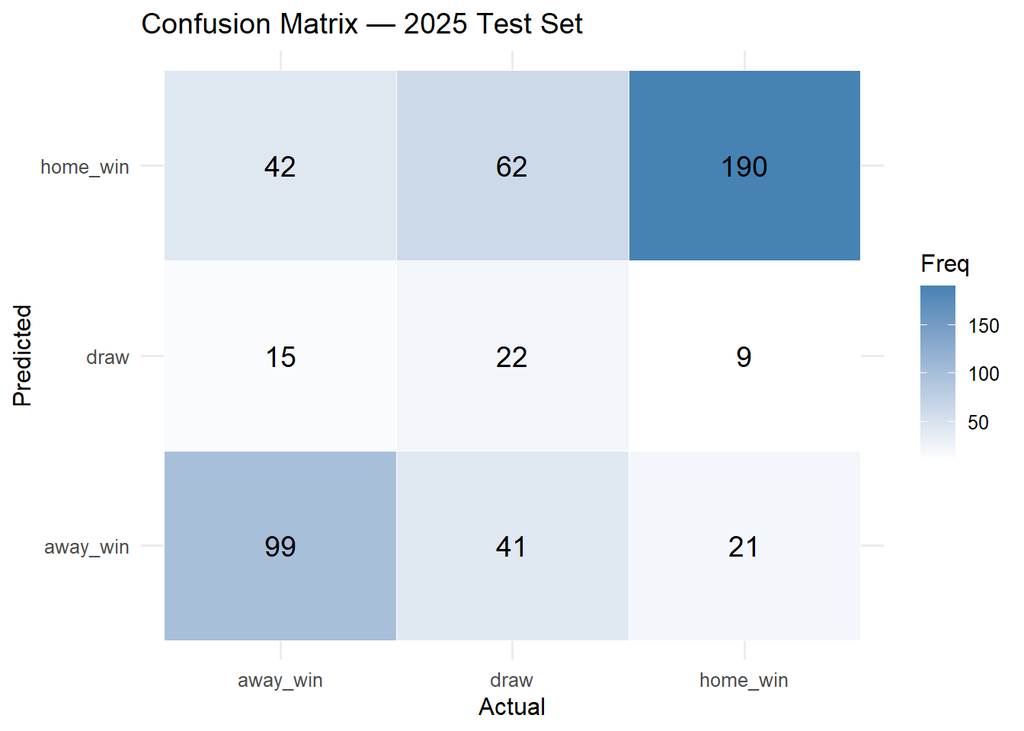

```r
# Plot confusion matrix
cm_df <- as.data.frame(cm$table)
ggplot(cm_df, aes(x = Reference, y = Prediction, fill = Freq)) +
  geom_tile(colour = "white") +
  geom_text(aes(label = Freq), size = 5) +
  scale_fill_gradient(low = "white", high = "steelblue") +
  labs(title = "Confusion Matrix — 2025 Test Set",
       x = "Actual", y = "Predicted") +
  theme_minimal(base_size = 12)
```

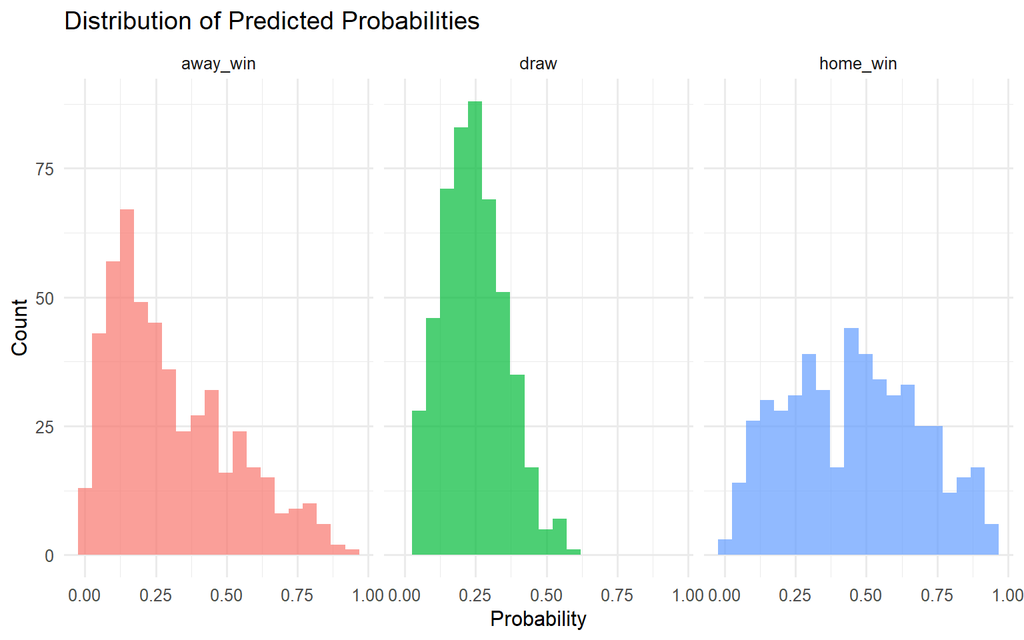

```r
# Predicted probabilities distribution
probs <- as.data.frame(predict(rf_model, X_test, type = "prob"))
probs$actual <- y_test

probs_long <- probs %>%
  tidyr::pivot_longer(-actual, names_to = "predicted_class", values_to = "probability")

ggplot(probs_long, aes(x = probability, fill = predicted_class)) +
  geom_histogram(bins = 20, alpha = 0.7, position = "identity") +
  facet_wrap(~predicted_class) +
  labs(title = "Distribution of Predicted Probabilities",
       x = "Probability", y = "Count") +
  theme_minimal(base_size = 12) +
  theme(legend.position = "none")
```

## 11. Retrain on 2024 + 2025

To predict 2026 matches, the model is retrained on all available historical data (2024 + 2025 combined).

```r
train_full_df <- df_model %>% filter(format(date, "%Y") %in% c("2024", "2025"))

X_full <- train_full_df[, final_features]
y_full <- train_full_df$result

set.seed(42)
rf_final <- randomForest(
  x       = X_full,
  y       = y_full,
  ntree   = 500,
  mtry    = floor(sqrt(length(final_features))),
  classwt = c(home_win = 1, away_win = 1, draw = 1)
)

cat("Final model trained on", nrow(train_full_df), "matches (2024 + 2025)\n")
```

```
## Final model trained on 985 matches (2024 + 2025)
```

## 12. 2026 Predictions & Validation

The model is applied to early 2026 matches. Since these results are already known, this section serves as an additional real-world validation of the model.

```
## 2026 matches available: 44
## Class distribution:
##
## away_win     draw home_win
##       12        6       26
##
## 2026 Prediction Accuracy: 68.2 %
##    match_id       date   result predicted correct prob_home prob_draw prob_away
## 1  08e147bc 2026-03-07     draw  home_win   FALSE      0.73      0.20      0.07
## 2  12769fea 2026-02-28 home_win      draw   FALSE      0.25      0.51      0.24
## 3  1b022c5c 2026-02-21 home_win  home_win    TRUE      0.58      0.26      0.16
## 4  2046cddd 2026-02-21 home_win  home_win    TRUE      0.37      0.27      0.36
## 5  245c0550 2026-02-21 home_win  home_win    TRUE      0.95      0.04      0.01
## 6  2f937f25 2026-02-28 away_win      draw   FALSE      0.22      0.40      0.38
## 7  314976c2 2026-02-21     draw  away_win   FALSE      0.14      0.32      0.55
```

[output cut: 37 more lines]

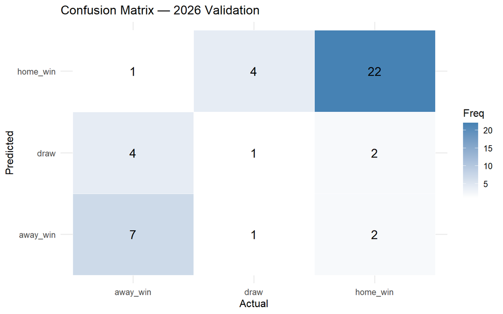

```r
predict_2026 <- df_model %>% filter(format(date, "%Y") == "2026")

if (nrow(predict_2026) == 0) {
  cat("No 2026 data available yet — update team_stats in the DB and reknit.\n")
} else {
  cat("2026 matches available:", nrow(predict_2026), "\n")
  cat("Class distribution:\n")
  print(table(predict_2026$result))

  X_2026 <- predict_2026[, final_features]
  y_2026 <- predict_2026$result
  y_pred_2026 <- predict(rf_final, X_2026)
  probs_2026 <- as.data.frame(predict(rf_final, X_2026, type = "prob"))
  acc_2026 <- mean(y_pred_2026 == y_2026)

  cat("\n2026 Prediction Accuracy:", round(acc_2026 * 100, 1), "%\n")

  results_2026 <- predict_2026 %>%
    select(match_id, date, result) %>%
    mutate(
      predicted  = y_pred_2026,
      correct    = result == predicted,
      prob_home  = round(probs_2026$home_win, 2),
      prob_draw  = round(probs_2026$draw, 2),
      prob_away  = round(probs_2026$away_win, 2)
    )

  print(results_2026)

  cm_2026 <- confusionMatrix(y_pred_2026, y_2026)
  cm_2026_df <- as.data.frame(cm_2026$table)

  ggplot(cm_2026_df, aes(x = Reference, y = Prediction, fill = Freq)) +
    geom_tile(colour = "white") +
    geom_text(aes(label = Freq), size = 5) +
    scale_fill_gradient(low = "white", high = "steelblue") +
    labs(
      title = "Confusion Matrix — 2026 Validation",
      x = "Actual", y = "Predicted"
    ) +
    theme_minimal(base_size = 12)
}
```

## 13. Summary

```r
summary_df <- data.frame(
  Stage = c("Feature screening", "Temporal split", "Test accuracy (2025)", "2026 validation accuracy"),
  Value = c(
    paste0(length(final_features), " features selected from 227"),
    paste0(nrow(train_df), " train / ", nrow(test_df), " test"),
    paste0(round(acc * 100, 1), "%"),
    ifelse(exists("acc_2026"), paste0(round(acc_2026 * 100, 1), "%"), "Pending — DB update required")
  )
)

knitr::kable(summary_df, col.names = c("Stage", "Result"))
```

| Stage | Result |
| --- | --- |
| Feature screening | 12 features selected from 227 |
| Temporal split | 484 train / 501 test |
| Test accuracy (2025) | 62.1% |
| 2026 validation accuracy | 68.2% |